# Analysis of /r/BEfire survey data

# Main investment strategy by age group

```r
data_distinct_main_strategy <- data_cleaned %>%
  distinct(main_strategy) %>%
  drop_na()

data_counts_age_main_strategy_temp <-
  expand.grid(main_strategy = data_distinct_main_strategy$main_strategy,
              age = data_counts_age$age)

data_counts_age_main_strategy <- data_cleaned %>%
  count(age, main_strategy) %>%
  # full_join(data_counts_age_main_strategy_temp, by = c("age", "main_strategy")) %>%
  # mutate(n = ifelse(is.na(n), 0, n)) %>%
  full_join(data_counts_age, by = "age") %>%
  mutate(percent_age = n/n_age*100,
         percent_total = n/sum(n)*100) %>%
  drop_na()
```

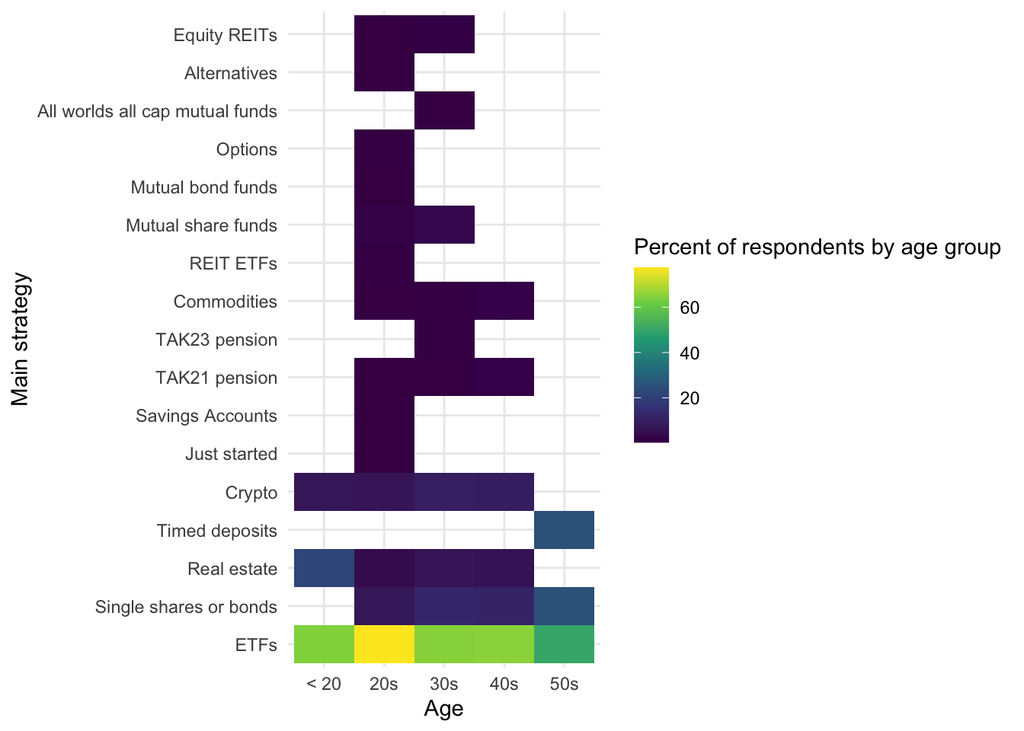

```r
ggplot(data_counts_age_main_strategy, aes(age, main_strategy, fill = percent_age)) +
  geom_tile() +
  scale_fill_viridis_c()  +
  labs(x = "Age",
       y = "Main strategy",
       fill = "Percent of respondents by age group") +
  theme_minimal()
```

- Timed deposit savings accounts are only of interest as a main strategy to the over 50s, and crypto is only of interest to the under 50s.
- TAK21 and TAK23 pension savings are relatively unpopular.
- ETFs are the most popular main strategy within all age groups. ETFs, share/bond picking, real estate, timed depoit savings accounts, and crypto make up the large majority of strategies being used within all age brackets.

# Target portfolio size by age group

```r
data_distinct_target_size <- data_cleaned %>%
  distinct(target_size) %>%
  drop_na()

data_counts_age_target_size_temp <-
  expand.grid(target_size = data_distinct_target_size$target_size,
              age = data_counts_age$age)

data_counts_age_target_size <- data_cleaned %>%
  count(age, target_size) %>%
  # full_join(data_counts_age_target_size_temp, by = c("age", "target_size")) %>%
  # mutate(n = ifelse(is.na(n), 0, n)) %>%
  full_join(data_counts_age, by = "age") %>%
  mutate(percent_age = n/n_age*100,
         percent_total = n/sum(n)*100) %>%
  drop_na()
```

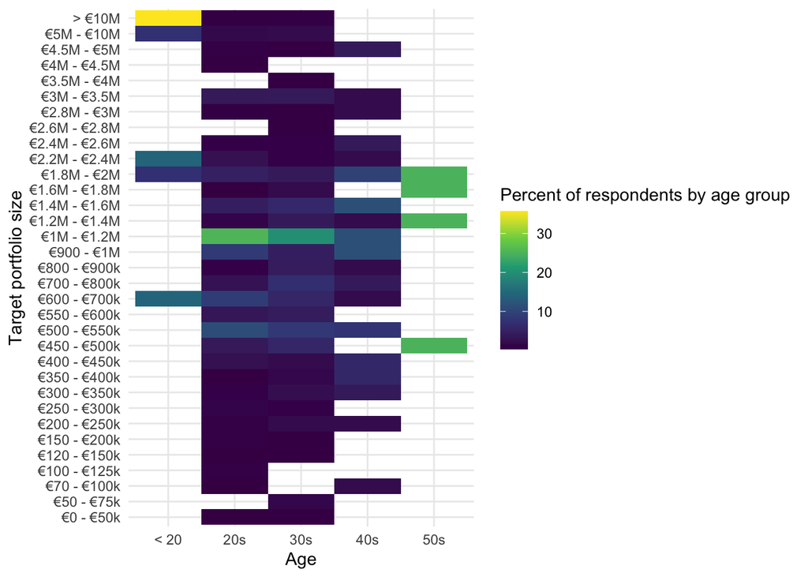

```r
ggplot(data_counts_age_target_size, aes(age, target_size, fill = percent_age)) +
  geom_tile() +
  scale_fill_viridis_c()  +
  labs(x = "Age",
       y = "Target portfolio size",
       fill = "Percent of respondents by age group") +
  theme_minimal()
```